# Chapter3. Pandas数据分析

## 3.4 数据规整

在很多应用中，数据可能分布在多个数据表中，或是以某种不易于分析的形式进行排列。这就需要通过合并、重塑、分组等操作将数据进行规整，从而进行下一步的分析。

### 3.4.1 MultiIndex 分层索引

分层索引（Hierarchical Indexing）是pandas的一个重要特性，允许在一个轴向上拥有多个索引层级，提供了一种在更低维度的形式中处理更高维度数据的方式。

#### ① Series分层索引

```python
arrays = [np.array(['A','A','B','B','C','C','D','D']),
          np.array(['one','two']*4)]
s = pd.Series(np.random.randn(8),index=arrays)  # index传递一个嵌套列表
s
```

```
A  one   -0.930209
   two   -1.588806
B  one    0.264771
   two   -0.331895
C  one   -0.810941
   two   -0.340369
D  one    0.770995
   two    0.101963
dtype: float64
```

```python
s.index  # 属于MultiIndex
```

```
MultiIndex([('A', 'one'),
            ('A', 'two'),
            ('B', 'one'),
            ('B', 'two'),
            ('C', 'one'),
            ('C', 'two'),
            ('D', 'one'),
            ('D', 'two')],
           )
```

```python
s.index.nlevels  # 查看索引层数
```

```
2
```

```python
s.index.levels[0]  # 查看0层索引的值
```

```
Index(['A', 'B', 'C', 'D'], dtype='object')
```

```python
s.index.levels[1]  # 查看1层索引的值
```

```
Index(['one', 'two'], dtype='object')
```

```python
# 部分索引，选择出数据的子集
s['A'] # 外层索引，返回单层索引Series
```

```
one   -0.930209
two   -1.588806
dtype: float64
```

```python
s[:,'two']  # 内层索引，返回单层索引Series
```

```
A   -1.588806
B   -0.331895
C   -0.340369
D    0.101963
dtype: float64
```

```python
s['A':'C']  # 切片，返回双层索引Series
```

```
A  one   -0.930209
   two   -1.588806
B  one    0.264771
   two   -0.331895
C  one   -0.810941
   two   -0.340369
dtype: float64
```

```python
s[['C','A']]  # 切片，返回双层索引Series
```

```
C  one   -0.810941
   two   -0.340369
A  one   -0.930209
   two   -1.588806
dtype: float64
```

#### ② DataFrame分层索引

```python
pd.DataFrame(np.random.randn(8,6),index=arrays)  # index传递一个嵌套列表
```

|  |  | 0 | 1 | 2 | 3 | 4 | 5 |
| --- | --- | --- | --- | --- | --- | --- | --- |
| A | one | -0.940440 | -0.037871 | -1.040771 | 1.255356 | 1.310486 | 1.041809 |
|  | two | -0.893592 | 0.711186 | -0.344407 | -0.863148 | -1.000205 | -0.867559 |
| B | one | -0.697457 | -0.279824 | 0.531483 | 0.409593 | -0.128293 | -0.051181 |
|  | two | 1.139589 | -0.976248 | 0.926989 | -1.629949 | 0.880810 | 0.410530 |
| C | one | -0.998798 | 0.849216 | 0.097098 | -1.876563 | -0.493390 | -0.296503 |
|  | two | 1.535550 | -0.407515 | -0.967563 | 0.405717 | -0.006821 | -1.474402 |
| D | one | 0.870614 | -0.919191 | 0.652835 | -1.094853 | -1.757276 | -0.881891 |
|  | two | 0.115961 | -0.325956 | 0.448788 | -0.315206 | -0.735808 | -0.536128 |

```python
df = pd.DataFrame(np.random.randn(6,8),
                  index=[['10-01','10-01','10-02','10-02','10-03','10-03'],['am','pm']*3],
                  columns=arrays)  # index和columns均传递嵌套列表
df
```

|  |  | A one | A two | B one | B two | C one | C two | D one | D two |
| --- | --- | --- | --- | --- | --- | --- | --- | --- | --- |
| 10-01 | am | 0.206035 | -1.598450 | 0.020393 | 1.845652 | 1.280762 | 0.783671 | 0.416483 | 1.358326 |
|  | pm | 2.369020 | 1.294497 | 0.724314 | 2.381351 | -0.857084 | 0.233799 | -0.021935 | 1.386907 |
| 10-02 | am | 0.605920 | 0.597151 | -1.981309 | -0.927168 | -0.357085 | 0.254756 | -0.069032 | 0.328008 |
|  | pm | -0.545819 | -0.873552 | 2.201534 | 0.373916 | -0.170433 | 0.190171 | 0.768081 | 1.263192 |
| 10-03 | am | 0.401408 | -0.472497 | -2.690754 | 0.543410 | -0.676735 | -1.055101 | -1.007701 | 0.726503 |
|  | pm | 0.705254 | 0.002740 | 0.266226 | -1.423825 | 1.510985 | 1.033017 | -0.126757 | 2.333499 |

```python
df.index  # index轴向上拥有两个索引层级
```

```
MultiIndex([('10-01', 'am'),
            ('10-01', 'pm'),
            ('10-02', 'am'),
            ('10-02', 'pm'),
            ('10-03', 'am'),
            ('10-03', 'pm')],
           )
```

```python
df.columns  # columns轴向上拥有两个索引层级
```

```
MultiIndex([('A', 'one'),
            ('A', 'two'),
            ('B', 'one'),
            ('B', 'two'),
            ('C', 'one'),
            ('C', 'two'),
            ('D', 'one'),
            ('D', 'two')],
           )
```

```python
# 选择列
df[('A','one')]
```

```
10-01  am    0.206035
       pm    2.369020
10-02  am    0.605920
       pm   -0.545819
10-03  am    0.401408
       pm    0.705254
Name: (A, one), dtype: float64
```

```python
df[[('A','one'),('B','two')]]
```

|  |  | A one | B two |
| --- | --- | --- | --- |
| 10-01 | am | 0.206035 | 1.845652 |
|  | pm | 2.369020 | 2.381351 |
| 10-02 | am | 0.605920 | -0.927168 |
|  | pm | -0.545819 | 0.373916 |
| 10-03 | am | 0.401408 | 0.543410 |
|  | pm | 0.705254 | -1.423825 |

```python
# 行索引
df[2:3]
```

|  |  | A one | A two | B one | B two | C one | C two | D one | D two |
| --- | --- | --- | --- | --- | --- | --- | --- | --- | --- |
| 10-02 | am | 0.60592 | 0.597151 | -1.981309 | -0.927168 | -0.357085 | 0.254756 | -0.069032 | 0.328008 |

```python
df.loc[('10-02','am')]
```

```
A  one    0.605920
   two    0.597151
B  one   -1.981309
   two   -0.927168
C  one   -0.357085
   two    0.254756
D  one   -0.069032
   two    0.328008
Name: (10-02, am), dtype: float64
```

```python
# 行与列索引
df.loc[('10-02','pm'),('B','two')]
```

```
0.37391566173991964
```

```python
# 索引层级命名
df.index.names=['date','time']
df.columns.names=['key1','key2']
df
```

| date | key1 key2 time | A one | A two | B one | B two | C one | C two | D one | D two |
| --- | --- | --- | --- | --- | --- | --- | --- | --- | --- |
| 10-01 | am | 0.206035 | -1.598450 | 0.020393 | 1.845652 | 1.280762 | 0.783671 | 0.416483 | 1.358326 |
|  | pm | 2.369020 | 1.294497 | 0.724314 | 2.381351 | -0.857084 | 0.233799 | -0.021935 | 1.386907 |
| 10-02 | am | 0.605920 | 0.597151 | -1.981309 | -0.927168 | -0.357085 | 0.254756 | -0.069032 | 0.328008 |
|  | pm | -0.545819 | -0.873552 | 2.201534 | 0.373916 | -0.170433 | 0.190171 | 0.768081 | 1.263192 |
| 10-03 | am | 0.401408 | -0.472497 | -2.690754 | 0.543410 | -0.676735 | -1.055101 | -1.007701 | 0.726503 |
|  | pm | 0.705254 | 0.002740 | 0.266226 | -1.423825 | 1.510985 | 1.033017 | -0.126757 | 2.333499 |

#### ③ 层级排序

1. `swaplevel()`方法: 重新排列某一轴上的层级顺序，返回一个变更了层级的新对象，但是数据是不变的；
2. `sort_index()`方法: 按照index进行排序，数据顺序会发生变化。

```python
df.swaplevel('date','time')  # 更换date和time的层级顺序
# df.swaplevel(0,1)
```

| time | key1 key2 date | A one | A two | B one | B two | C one | C two | D one | D two |
| --- | --- | --- | --- | --- | --- | --- | --- | --- | --- |
| am | 10-01 | 0.206035 | -1.598450 | 0.020393 | 1.845652 | 1.280762 | 0.783671 | 0.416483 | 1.358326 |
| pm | 10-01 | 2.369020 | 1.294497 | 0.724314 | 2.381351 | -0.857084 | 0.233799 | -0.021935 | 1.386907 |
| am | 10-02 | 0.605920 | 0.597151 | -1.981309 | -0.927168 | -0.357085 | 0.254756 | -0.069032 | 0.328008 |
| pm | 10-02 | -0.545819 | -0.873552 | 2.201534 | 0.373916 | -0.170433 | 0.190171 | 0.768081 | 1.263192 |
| am | 10-03 | 0.401408 | -0.472497 | -2.690754 | 0.543410 | -0.676735 | -1.055101 | -1.007701 | 0.726503 |
| pm | 10-03 | 0.705254 | 0.002740 | 0.266226 | -1.423825 | 1.510985 | 1.033017 | -0.126757 | 2.333499 |

```python
df.sort_index(level=1)   # level=1表示按照层级time进行字典排序
```

| date | key1 key2 time | A one | A two | B one | B two | C one | C two | D one | D two |
| --- | --- | --- | --- | --- | --- | --- | --- | --- | --- |
| 10-01 | am | 0.206035 | -1.598450 | 0.020393 | 1.845652 | 1.280762 | 0.783671 | 0.416483 | 1.358326 |
| 10-02 | am | 0.605920 | 0.597151 | -1.981309 | -0.927168 | -0.357085 | 0.254756 | -0.069032 | 0.328008 |
| 10-03 | am | 0.401408 | -0.472497 | -2.690754 | 0.543410 | -0.676735 | -1.055101 | -1.007701 | 0.726503 |
| 10-01 | pm | 2.369020 | 1.294497 | 0.724314 | 2.381351 | -0.857084 | 0.233799 | -0.021935 | 1.386907 |
| 10-02 | pm | -0.545819 | -0.873552 | 2.201534 | 0.373916 | -0.170433 | 0.190171 | 0.768081 | 1.263192 |
| 10-03 | pm | 0.705254 | 0.002740 | 0.266226 | -1.423825 | 1.510985 | 1.033017 | -0.126757 | 2.333499 |

```python
# 层级变换（swaplevel）后，通常会同时使用sort_index使数据顺序按照层级进行字典排序。
df.swaplevel('date','time').sort_index()
```

| time | key1 key2 date | A one | A two | B one | B two | C one | C two | D one | D two |
| --- | --- | --- | --- | --- | --- | --- | --- | --- | --- |
| am | 10-01 | 0.206035 | -1.598450 | 0.020393 | 1.845652 | 1.280762 | 0.783671 | 0.416483 | 1.358326 |
|  | 10-02 | 0.605920 | 0.597151 | -1.981309 | -0.927168 | -0.357085 | 0.254756 | -0.069032 | 0.328008 |
|  | 10-03 | 0.401408 | -0.472497 | -2.690754 | 0.543410 | -0.676735 | -1.055101 | -1.007701 | 0.726503 |
| pm | 10-01 | 2.369020 | 1.294497 | 0.724314 | 2.381351 | -0.857084 | 0.233799 | -0.021935 | 1.386907 |
|  | 10-02 | -0.545819 | -0.873552 | 2.201534 | 0.373916 | -0.170433 | 0.190171 | 0.768081 | 1.263192 |
|  | 10-03 | 0.705254 | 0.002740 | 0.266226 | -1.423825 | 1.510985 | 1.033017 | -0.126757 | 2.333499 |

```python
df.swaplevel('key1','key2',axis=1).sort_index(axis=1)
```

| date | key2 key1 time | one A | one B | one C | one D | two A | two B | two C | two D |
| --- | --- | --- | --- | --- | --- | --- | --- | --- | --- |
| 10-01 | am | 0.206035 | 0.020393 | 1.280762 | 0.416483 | -1.598450 | 1.845652 | 0.783671 | 1.358326 |
|  | pm | 2.369020 | 0.724314 | -0.857084 | -0.021935 | 1.294497 | 2.381351 | 0.233799 | 1.386907 |
| 10-02 | am | 0.605920 | -1.981309 | -0.357085 | -0.069032 | 0.597151 | -0.927168 | 0.254756 | 0.328008 |
|  | pm | -0.545819 | 2.201534 | -0.170433 | 0.768081 | -0.873552 | 0.373916 | 0.190171 | 1.263192 |
| 10-03 | am | 0.401408 | -2.690754 | -0.676735 | -1.007701 | -0.472497 | 0.543410 | -1.055101 | 0.726503 |
|  | pm | 0.705254 | 0.266226 | 1.510985 | -0.126757 | 0.002740 | -1.423825 | 1.033017 | 2.333499 |

#### ④ 按层级汇总统计

```python
df
```

| date | key1 key2 time | A one | A two | B one | B two | C one | C two | D one | D two |
| --- | --- | --- | --- | --- | --- | --- | --- | --- | --- |
| 10-01 | am | 0.206035 | -1.598450 | 0.020393 | 1.845652 | 1.280762 | 0.783671 | 0.416483 | 1.358326 |
|  | pm | 2.369020 | 1.294497 | 0.724314 | 2.381351 | -0.857084 | 0.233799 | -0.021935 | 1.386907 |
| 10-02 | am | 0.605920 | 0.597151 | -1.981309 | -0.927168 | -0.357085 | 0.254756 | -0.069032 | 0.328008 |
|  | pm | -0.545819 | -0.873552 | 2.201534 | 0.373916 | -0.170433 | 0.190171 | 0.768081 | 1.263192 |
| 10-03 | am | 0.401408 | -0.472497 | -2.690754 | 0.543410 | -0.676735 | -1.055101 | -1.007701 | 0.726503 |
|  | pm | 0.705254 | 0.002740 | 0.266226 | -1.423825 | 1.510985 | 1.033017 | -0.126757 | 2.333499 |

```python
df.sum()
```

```
key1  key2
A     one     3.741818
      two    -1.050110
B     one    -1.459596
      two     2.793335
C     one     0.730410
      two     1.440313
D     one    -0.040862
      two     7.396436
dtype: float64
```

```python
df.sum(level='time')
# df.sum(axis=0,level=1)
```

| key1 key2 time | A one | A two | B one | B two | C one | C two | D one | D two |
| --- | --- | --- | --- | --- | --- | --- | --- | --- |
| am | 1.213363 | -1.473796 | -4.651670 | 1.461894 | 0.246941 | -0.016674 | -0.660250 | 2.412837 |
| pm | 2.528455 | 0.423685 | 3.192074 | 1.331442 | 0.483469 | 1.456987 | 0.619388 | 4.983599 |

```python
# 使用groupby改写
df.groupby(level=1).sum()
```

| key1 key2 time | A one | A two | B one | B two | C one | C two | D one | D two |
| --- | --- | --- | --- | --- | --- | --- | --- | --- |
| am | 1.213363 | -1.473796 | -4.651670 | 1.461894 | 0.246941 | -0.016674 | -0.660250 | 2.412837 |
| pm | 2.528455 | 0.423685 | 3.192074 | 1.331442 | 0.483469 | 1.456987 | 0.619388 | 4.983599 |

```python
df.mean(axis=1,level='key1')
# df.mean(axis=1,level=0)
```

| date | key1 time | A | B | C | D |
| --- | --- | --- | --- | --- | --- |
| 10-01 | am | -0.696207 | 0.933022 | 1.032216 | 0.887405 |
|  | pm | 1.831759 | 1.552833 | -0.311642 | 0.682486 |
| 10-02 | am | 0.601535 | -1.454239 | -0.051165 | 0.129488 |
|  | pm | -0.709686 | 1.287725 | 0.009869 | 1.015637 |
| 10-03 | am | -0.035545 | -1.073672 | -0.865918 | -0.140599 |
|  | pm | 0.353997 | -0.578800 | 1.272001 | 1.103371 |

```python
# 使用groupby改写
df.groupby(axis=1,level='key1').mean()
```

| date | key1 time | A | B | C | D |
| --- | --- | --- | --- | --- | --- |
| 10-01 | am | -0.696207 | 0.933022 | 1.032216 | 0.887405 |
|  | pm | 1.831759 | 1.552833 | -0.311642 | 0.682486 |
| 10-02 | am | 0.601535 | -1.454239 | -0.051165 | 0.129488 |
|  | pm | -0.709686 | 1.287725 | 0.009869 | 1.015637 |
| 10-03 | am | -0.035545 | -1.073672 | -0.865918 | -0.140599 |
|  | pm | 0.353997 | -0.578800 | 1.272001 | 1.103371 |

### 3.4.2 Merge 数据表合并

#### ① 数据库风格的DataFrame连接

`merge()`函数可以根据一个或多个键进行多表连接，与SQL或其它关系型数据库的连接操作比较相似。

该函数的参数how表示不同连接类型：

- inner：只对两张表的键的交集进行联合；
- left：对所有左表的键进行联合；
- right：对所有右表的键进行联合；
- outer：对两张表的键的并集进行联合。

```python
# 1. 一对多的连接
df1 = pd.DataFrame({'key':['b','b','a','c','a','a','b'],
                    'lval':range(7)})
df1
```

|  | key | lval |
| --- | --- | --- |
| 0 | b | 0 |
| 1 | b | 1 |
| 2 | a | 2 |
| 3 | c | 3 |
| 4 | a | 4 |
| 5 | a | 5 |
| 6 | b | 6 |

```python
df2 = pd.DataFrame({'key':['a','b','d'],
                    'rval':range(3)})
df2
```

|  | key | rval |
| --- | --- | --- |
| 0 | a | 0 |
| 1 | b | 1 |
| 2 | d | 2 |

```python
pd.merge(df1,df2,on='key')  # 默认how='inner'：只对两张表都有的键的交集进行联合
```

|  | key | lval | rval |
| --- | --- | --- | --- |
| 0 | b | 0 | 1 |
| 1 | b | 1 | 1 |
| 2 | b | 6 | 1 |
| 3 | a | 2 | 0 |
| 4 | a | 4 | 0 |
| 5 | a | 5 | 0 |

```python
# 如果两张表列名不同，可以分别传递left_on和right_on参数指定列名
df3 = pd.DataFrame({'lkey':['b','b','a','c','a','a','b'],
                    'lval':range(7)})
df4 = pd.DataFrame({'rkey':['a','b','d'],
                    'rval':range(3)})
pd.merge(df3,df4,left_on='lkey',right_on='rkey')
```

|  | lkey | lval | rkey | rval |
| --- | --- | --- | --- | --- |
| 0 | b | 0 | b | 1 |
| 1 | b | 1 | b | 1 |
| 2 | b | 6 | b | 1 |
| 3 | a | 2 | a | 0 |
| 4 | a | 4 | a | 0 |
| 5 | a | 5 | a | 0 |

```python
pd.merge(df1,df2,how='outer')  # outer: 对两张表都有的键的并集进行联合
```

|  | key | lval | rval |
| --- | --- | --- | --- |
| 0 | b | 0.0 | 1.0 |
| 1 | b | 1.0 | 1.0 |
| 2 | b | 6.0 | 1.0 |
| 3 | a | 2.0 | 0.0 |
| 4 | a | 4.0 | 0.0 |
| 5 | a | 5.0 | 0.0 |
| 6 | c | 3.0 | NaN |
| 7 | d | NaN | 2.0 |

```python
pd.merge(df1,df2,how='left')  # left: 对所有左表的键进行联合
```

|  | key | lval | rval |
| --- | --- | --- | --- |
| 0 | b | 0 | 1.0 |
| 1 | b | 1 | 1.0 |
| 2 | a | 2 | 0.0 |
| 3 | c | 3 | NaN |
| 4 | a | 4 | 0.0 |
| 5 | a | 5 | 0.0 |
| 6 | b | 6 | 1.0 |

```python
pd.merge(df1,df2,how='right')  # right: 对所有右表的键进行联合
```

|  | key | lval | rval |
| --- | --- | --- | --- |
| 0 | a | 2.0 | 0 |
| 1 | a | 4.0 | 0 |
| 2 | a | 5.0 | 0 |
| 3 | b | 0.0 | 1 |
| 4 | b | 1.0 | 1 |
| 5 | b | 6.0 | 1 |
| 6 | d | NaN | 2 |

```python
# 2. 一对一的连接
left = pd.DataFrame({'key':['a','b','c'],
                     'lval':[1,2,3]})
left
```

|  | key | lval |
| --- | --- | --- |
| 0 | a | 1 |
| 1 | b | 2 |
| 2 | c | 3 |

```python
right = pd.DataFrame({'key':['a','b','d'],
                      'rval':[4,5,6]})
right
```

|  | key | rval |
| --- | --- | --- |
| 0 | a | 4 |
| 1 | b | 5 |
| 2 | d | 6 |

```python
pd.merge(left,right)
```

|  | key | lval | rval |
| --- | --- | --- | --- |
| 0 | a | 1 | 4 |
| 1 | b | 2 | 5 |

```python
pd.merge(left,right,how='left')
```

|  | key | lval | rval |
| --- | --- | --- | --- |
| 0 | a | 1 | 4.0 |
| 1 | b | 2 | 5.0 |
| 2 | c | 3 | NaN |

```python
pd.merge(left,right,how='right')
```

|  | key | lval | rval |
| --- | --- | --- | --- |
| 0 | a | 1.0 | 4 |
| 1 | b | 2.0 | 5 |
| 2 | d | NaN | 6 |

```python
pd.merge(left,right,how='outer')
```

|  | key | lval | rval |
| --- | --- | --- | --- |
| 0 | a | 1.0 | 4.0 |
| 1 | b | 2.0 | 5.0 |
| 2 | c | 3.0 | NaN |
| 3 | d | NaN | 6.0 |

```python
# 3. 多对多的连接
left = pd.DataFrame({'key':['a','b','a'],
                     'lval':[1,2,3]})
left
```

|  | key | lval |
| --- | --- | --- |
| 0 | a | 1 |
| 1 | b | 2 |
| 2 | a | 3 |

```python
right = pd.DataFrame({'key':['a','c','a'],
                      'rval':[4,5,6]})
right
```

|  | key | rval |
| --- | --- | --- |
| 0 | a | 4 |
| 1 | c | 5 |
| 2 | a | 6 |

```python
pd.merge(left,right)  # 行的笛卡尔积：left有2个a，right有2个a，结果会返回2*2行
```

|  | key | lval | rval |
| --- | --- | --- | --- |
| 0 | a | 1 | 4 |
| 1 | a | 1 | 6 |
| 2 | a | 3 | 4 |
| 3 | a | 3 | 6 |

```python
pd.merge(left,right,how='left')
```

|  | key | lval | rval |
| --- | --- | --- | --- |
| 0 | a | 1 | 4.0 |
| 1 | a | 1 | 6.0 |
| 2 | b | 2 | NaN |
| 3 | a | 3 | 4.0 |
| 4 | a | 3 | 6.0 |

```python
pd.merge(left,right,how='right')
```

|  | key | lval | rval |
| --- | --- | --- | --- |
| 0 | a | 1.0 | 4 |
| 1 | a | 3.0 | 4 |
| 2 | c | NaN | 5 |
| 3 | a | 1.0 | 6 |
| 4 | a | 3.0 | 6 |

```python
pd.merge(left,right,how='outer')
```

|  | key | lval | rval |
| --- | --- | --- | --- |
| 0 | a | 1.0 | 4.0 |
| 1 | a | 1.0 | 6.0 |
| 2 | a | 3.0 | 4.0 |
| 3 | a | 3.0 | 6.0 |
| 4 | b | 2.0 | NaN |
| 5 | c | NaN | 5.0 |

#### ② 根据索引合并

在某些情况下，DataFrame用于合并的键并不是某一列，而是它的索引。这时可以传递merge函数的参数left_index=True或者right_index=True来表示将索引作为合并的键。

```python
df2 = pd.DataFrame({'rval':range(3)},index=['a','b','d'])
df2
```

|  | rval |
| --- | --- |
| a | 0 |
| b | 1 |
| d | 2 |

```python
df1
```

|  | key | lval |
| --- | --- | --- |
| 0 | b | 0 |
| 1 | b | 1 |
| 2 | a | 2 |
| 3 | c | 3 |
| 4 | a | 4 |
| 5 | a | 5 |
| 6 | b | 6 |

```python
pd.merge(df1,df2,left_on='key',right_index=True)  # df1的key列和df2的索引作为合并的键
```

|  | key | lval | rval |
| --- | --- | --- | --- |
| 0 | b | 0 | 1 |
| 1 | b | 1 | 1 |
| 6 | b | 6 | 1 |
| 2 | a | 2 | 0 |
| 4 | a | 4 | 0 |
| 5 | a | 5 | 0 |

```python
df5 = pd.DataFrame({'lval':range(7)},index=['b','b','a','c','a','a','b'] )
df5
```

|  | lval |
| --- | --- |
| b | 0 |
| b | 1 |
| a | 2 |
| c | 3 |
| a | 4 |
| a | 5 |
| b | 6 |

```python
pd.merge(df5,df2,left_index=True,right_index=True)  # 两个DataFrame对象合并的键都是index
```

|  | lval | rval |
| --- | --- | --- |
| a | 2 | 0 |
| a | 4 | 0 |
| a | 5 | 0 |
| b | 0 | 1 |
| b | 1 | 1 |
| b | 6 | 1 |

DataFrame有一个方便的`join()`方法，用于根据索引合并（默认左连接）

```python
df5.join(df2,how='inner')  # .jion方法默认实现左连接，也可通过how参数更改
```

|  | lval | rval |
| --- | --- | --- |
| a | 2 | 0 |
| a | 4 | 0 |
| a | 5 | 0 |
| b | 0 | 1 |
| b | 1 | 1 |
| b | 6 | 1 |

```python
# 使用join方法实现根据索引合并
df5.join(df2)
```

|  | lval | rval |
| --- | --- | --- |
| a | 2 | 0.0 |
| a | 4 | 0.0 |
| a | 5 | 0.0 |
| b | 0 | 1.0 |
| b | 1 | 1.0 |
| b | 6 | 1.0 |
| c | 3 | NaN |

```python
pd.merge(df5,df2,left_index=True,right_index=True,how='left')  # 与上一写法相同，繁琐
```

|  | lval | rval |
| --- | --- | --- |
| a | 2 | 0.0 |
| a | 4 | 0.0 |
| a | 5 | 0.0 |
| b | 0 | 1.0 |
| b | 1 | 1.0 |
| b | 6 | 1.0 |
| c | 3 | NaN |

#### ③ 沿轴向连接

`concat()`函数使pandas对象能够在轴向上进行堆叠、拼接。

```python
# 1. Series的concat()
s = pd.Series(range(7),index=list('abcdefg'))
[s1,s2,s3]=[s[:2],s[2:5],s[5:]]  # 进行切片
s1
```

```
a    0
b    1
dtype: int64
```

```python
s2
```

```
c    2
d    3
e    4
dtype: int64
```

```python
s3
```

```
f    5
g    6
dtype: int64
```

```python
pd.concat([s1,s2,s3])  # 默认沿着axis=0方向堆叠
```

```
a    0
b    1
c    2
d    3
e    4
f    5
g    6
dtype: int64
```

```python
pd.concat([s1,s2,s3],axis=1)  # 更改轴向
```

|  | 0 | 1 | 2 |
| --- | --- | --- | --- |
| a | 0.0 | NaN | NaN |
| b | 1.0 | NaN | NaN |
| c | NaN | 2.0 | NaN |
| d | NaN | 3.0 | NaN |
| e | NaN | 4.0 | NaN |
| f | NaN | NaN | 5.0 |
| g | NaN | NaN | 6.0 |

```python
# 拼接后的各部分无法在结果中进行区分，可以传递keys参数创建一个多层索引用以区分
rs = pd.concat([s1,s1,s3],keys=['one','two','three'])
rs
```

```
one    a    0
       b    1
two    a    0
       b    1
three  f    5
       g    6
dtype: int64
```

```python
rs.index # 多层索引
```

```
MultiIndex([(  'one', 'a'),
            (  'one', 'b'),
            (  'two', 'a'),
            (  'two', 'b'),
            ('three', 'f'),
            ('three', 'g')],
           )
```

```python
rs = pd.concat([s1,s2,s3],axis=1,keys=['one','two','three']) # 更改轴向后keys成为columns
rs
```

|  | one | two | three |
| --- | --- | --- | --- |
| a | 0.0 | NaN | NaN |
| b | 1.0 | NaN | NaN |
| c | NaN | 2.0 | NaN |
| d | NaN | 3.0 | NaN |
| e | NaN | 4.0 | NaN |
| f | NaN | NaN | 5.0 |
| g | NaN | NaN | 6.0 |

```python
s4 = pd.concat([s1,s3])
s4
```

```
a    0
b    1
f    5
g    6
dtype: int64
```

```python
pd.concat([s1,s4],axis=1,join='inner')  # 默认拼接方式为outer，可以通过join参数更改
```

|  | 0 | 1 |
| --- | --- | --- |
| a | 0 | 0 |
| b | 1 | 1 |

```python
# 2. DataFrame的concat()
df1 = pd.DataFrame(np.arange(6).reshape(3,2),index=['a','b','c'],
                   columns=['x1','x2'])
df1
```

|  | x1 | x2 |
| --- | --- | --- |
| a | 0 | 1 |
| b | 2 | 3 |
| c | 4 | 5 |

```python
df2 = pd.DataFrame(np.arange(4).reshape(2,2),index=['a','c'],
                   columns=['x1','x3'])
df2
```

|  | x1 | x3 |
| --- | --- | --- |
| a | 0 | 1 |
| c | 2 | 3 |

```python
pd.concat([df1,df2])  # 默认沿axis=0方向进行拼接
```

|  | x1 | x2 | x3 |
| --- | --- | --- | --- |
| a | 0 | 1.0 | NaN |
| b | 2 | 3.0 | NaN |
| c | 4 | 5.0 | NaN |
| a | 0 | NaN | 1.0 |
| c | 2 | NaN | 3.0 |

```python
pd.concat([df1,df2],axis=1,keys=['one','two'])  # 更改方向，传递keys参数
```

|  | one x1 | one x2 | two x1 | two x3 |
| --- | --- | --- | --- | --- |
| a | 0 | 1 | 0.0 | 1.0 |
| b | 2 | 3 | NaN | NaN |
| c | 4 | 5 | 2.0 | 3.0 |

### 3.4.3 Reshaping 数据重塑

重排表格型数据有许多基础操作，这些操作被称为重塑或者透视。

#### ① Stack & unstack

1. stack（堆叠）：将列中的数据透视到行（columns --> index）
2. unstack（拆堆）：将行中的数据透视到列（index --> columns）

```python
df = pd.DataFrame(np.random.randn(3,4),
                  index=pd.date_range('20211001',periods=3),
                  columns=['A','B','C','D'])
df
```

|  | A | B | C | D |
| --- | --- | --- | --- | --- |
| 2021-10-01 | -0.558319 | 0.691437 | 0.376698 | 0.415550 |
| 2021-10-02 | -1.030821 | -1.221023 | 0.198985 | -0.164733 |
| 2021-10-03 | -0.945919 | -0.780948 | -0.202369 | 0.276033 |

```python
rs = df.stack()  # 将列中的数据透视到行
rs
```

```
2021-10-01  A   -0.558319
            B    0.691437
            C    0.376698
            D    0.415550
2021-10-02  A   -1.030821
            B   -1.221023
            C    0.198985
            D   -0.164733
2021-10-03  A   -0.945919
            B   -0.780948
            C   -0.202369
            D    0.276033
dtype: float64
```

```python
rs.index  # 返回一个多层索引的Series
```

```
MultiIndex([('2021-10-01', 'A'),
            ('2021-10-01', 'B'),
            ('2021-10-01', 'C'),
            ('2021-10-01', 'D'),
            ('2021-10-02', 'A'),
            ('2021-10-02', 'B'),
            ('2021-10-02', 'C'),
            ('2021-10-02', 'D'),
            ('2021-10-03', 'A'),
            ('2021-10-03', 'B'),
            ('2021-10-03', 'C'),
            ('2021-10-03', 'D')],
           )
```

```python
df.unstack()  # 将行中的数据透视到列，同样返回一个多层索引的Series
```

```
A  2021-10-01   -0.558319
   2021-10-02   -1.030821
   2021-10-03   -0.945919
B  2021-10-01    0.691437
   2021-10-02   -1.221023
   2021-10-03   -0.780948
C  2021-10-01    0.376698
   2021-10-02    0.198985
   2021-10-03   -0.202369
D  2021-10-01    0.415550
   2021-10-02   -0.164733
   2021-10-03    0.276033
dtype: float64
```

```python
rs.unstack()  # 对一个多层索引Series，使用unstack方法将数据重新排列成DataFrame对象
```

|  | A | B | C | D |
| --- | --- | --- | --- | --- |
| 2021-10-01 | -0.558319 | 0.691437 | 0.376698 | 0.415550 |
| 2021-10-02 | -1.030821 | -1.221023 | 0.198985 | -0.164733 |
| 2021-10-03 | -0.945919 | -0.780948 | -0.202369 | 0.276033 |

```python
rs.unstack(level=0)  # 默认情况下level=-1，即拆堆最内层，也可传递参数拆分不同层级
```

|  | 2021-10-01 | 2021-10-02 | 2021-10-03 |
| --- | --- | --- | --- |
| A | -0.558319 | -1.030821 | -0.945919 |
| B | 0.691437 | -1.221023 | -0.780948 |
| C | 0.376698 | 0.198985 | -0.202369 |
| D | 0.415550 | -0.164733 | 0.276033 |

```python
rs2 = rs.drop([('20211001','A'),('20211001','B')])  # 删除rs的几个值，并赋值给rs2
rs2
```

```
2021-10-01  C    0.376698
            D    0.415550
2021-10-02  A   -1.030821
            B   -1.221023
            C    0.198985
            D   -0.164733
2021-10-03  A   -0.945919
            B   -0.780948
            C   -0.202369
            D    0.276033
dtype: float64
```

```python
rs2.unstack()  # 会引入缺失值
```

|  | A | B | C | D |
| --- | --- | --- | --- | --- |
| 2021-10-01 | NaN | NaN | 0.376698 | 0.415550 |
| 2021-10-02 | -1.030821 | -1.221023 | 0.198985 | -0.164733 |
| 2021-10-03 | -0.945919 | -0.780948 | -0.202369 | 0.276033 |

```python
rs2.unstack().stack()  # 再次堆叠会自动过滤缺失值，因此stack和unstack操作是可逆的
```

```
2021-10-01  C    0.376698
            D    0.415550
2021-10-02  A   -1.030821
            B   -1.221023
            C    0.198985
            D   -0.164733
2021-10-03  A   -0.945919
            B   -0.780948
            C   -0.202369
            D    0.276033
dtype: float64
```

```python
rs2.unstack().stack(dropna=False)  # 也可自定义不过滤缺失值
```

```
2021-10-01  A         NaN
            B         NaN
            C    0.376698
            D    0.415550
2021-10-02  A   -1.030821
            B   -1.221023
            C    0.198985
            D   -0.164733
2021-10-03  A   -0.945919
            B   -0.780948
            C   -0.202369
            D    0.276033
dtype: float64
```

#### ② Pivot tables

```python
import pandas as pd
import numpy as np
```

```python
df = pd.DataFrame({'Name':['Alice','Andy','Bob']*4,
                   'Course':['English','Math','Gym','History']*3,
                   'Index':['A']*10+['B']*2,
                   'Data1':np.random.randint(60,100,size=12),
                   'Data2':np.random.randint(60,100,size=12)})
df.duplicated(['Name','Course'])
df
```

[output not shown]

```python
# 使用pivot函数，可以对表格型数据进行重塑
df.pivot_table(index=['Name','Course'],values=['Data1'])
```

| Name | Course | Data1 |
| --- | --- | --- |
| Alice | English | 67 |
|  | Gym | 63 |
|  | History | 68 |
|  | Math | 87 |
| Andy | English | 70 |
|  | Gym | 94 |
|  | History | 95 |
|  | Math | 72 |
| Bob | English | 84 |
|  | Gym | 90 |
|  | History | 72 |
|  | Math | 75 |

```python
df.pivot_table(index=['Course','Name'],values=['Data1'],columns=['Index'])  # 对数据进行重塑
```

| Course | Index Name | Data1 A | Data1 B |
| --- | --- | --- | --- |
| English | Alice | 67.0 | NaN |
|  | Andy | 70.0 | NaN |
|  | Bob | 84.0 | NaN |
| Gym | Alice | 63.0 | NaN |
|  | Andy | NaN | 94.0 |
|  | Bob | 90.0 | NaN |
| History | Alice | 68.0 | NaN |
|  | Andy | 95.0 | NaN |
|  | Bob | NaN | 72.0 |
| Math | Alice | 87.0 | NaN |
|  | Andy | 72.0 | NaN |
|  | Bob | 75.0 | NaN |

```python
df.pivot_table(index=['Name'],values=['Data1','Data2'],aggfunc='mean')  #增加aggfunc参数，可以对多个value值应用函数
```

| Name | Data1 | Data2 |
| --- | --- | --- |
| Alice | 71.25 | 76.75 |
| Andy | 82.75 | 77.25 |
| Bob | 80.25 | 76.00 |

### 3.4.4 Grouping 数据分组

#### ① GroupBy机制

我们经常会需要对数据集进行分组，并且在每一组上应用一个聚合函数或转换函数。pandas提供了一个灵活的groupby接口，允许对数据集进行分组和聚合操作。

1. split：依据条件（往往是一个或多个列）将数据拆分为多个组；
2. apply：对每个组内的数据单独应用函数，产生新的值；
3. combine：将每个组的新值返回为一个结果对象。

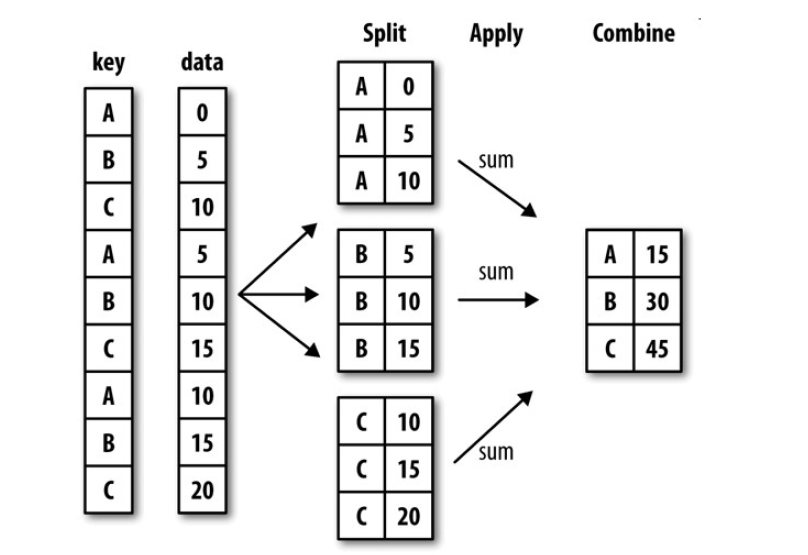

时间序列数据的聚合是groupby的特殊用例，被称为重采样，将在后期单独介绍。

```python
import pandas as pd
import numpy as np
df = pd.DataFrame({'Name':['Alice','Andy','Bob']*4,
                   'Course':['English','Math','Gym','History']*3,
                   'Data1':np.random.randint(60,100,size=12),
                   'Data2':np.random.randint(60,100,size=12)})
df.duplicated(['Name','Course'])
df
```

|  | Name | Course | Data1 | Data2 |
| --- | --- | --- | --- | --- |
| 0 | Alice | English | 70 | 85 |
| 1 | Andy | Math | 73 | 62 |
| 2 | Bob | Gym | 94 | 70 |
| 3 | Alice | History | 97 | 99 |
| 4 | Andy | English | 85 | 69 |
| 5 | Bob | Math | 71 | 94 |
| 6 | Alice | Gym | 93 | 70 |
| 7 | Andy | History | 73 | 80 |
| 8 | Bob | English | 73 | 84 |
| 9 | Alice | Math | 66 | 79 |
| 10 | Andy | Gym | 93 | 60 |
| 11 | Bob | History | 95 | 97 |

```python
# 先分组，后聚合
df.groupby('Name').mean()  # Course列非数值数据，自动排除
```

| Name | Data1 | Data2 |
| --- | --- | --- |
| Alice | 81.50 | 83.25 |
| Andy | 81.00 | 67.75 |
| Bob | 83.25 | 86.25 |

```python
# 根据Name标签分组，选择Data1列（对于大型数据集，只需要聚合少部分列）
df['Data1'].groupby(df['Name'])  # 返回的是一个GroupBy对象
```

```
<pandas.core.groupby.generic.SeriesGroupBy object at 0x000001A6048ADD00>
```

```python
df.groupby('Name')['Data1']  # 另一种可读性更好的写法，语法糖
```

```
<pandas.core.groupby.generic.SeriesGroupBy object at 0x000001A6045A8190>
```

```python
# 根据Name标签分组，求Data1列的平均值
df['Data1'].groupby(df['Name']).mean()
```

[output not shown]

```python
df.groupby('Name')['Data1'].mean()  # 语法糖
```

[output not shown]

```python
# 根据Course分组，计算Data2的总和
df['Data2'].groupby(df['Course']).sum()
```

[output not shown]

```python
df.groupby('Course')['Data2'].sum()   # 语法糖
```

[output not shown]

```python
# 应用多个函数
df.groupby('Course')['Data2'].agg(['mean','count'])
```

[output not shown]

```python
# 根据Name和Course分组，计算Data1的平均值
gp = df.groupby(['Name','Course'])['Data1'].mean()
gp  # 返回的是一个分层索引Series
```

[output not shown]

```python
gp['Alice'] # 查看Name为Alice的数据，返回的是索引为Course的Series
```

[output not shown]

#### ② 遍历各分组

分组后返回的是一个可迭代的GroupBy对象，是一个包含组名和数据块的二维元组序列。

```python
df.groupby('Name')  # 分组键为Name
```

```
<pandas.core.groupby.generic.DataFrameGroupBy object at 0x000001A60458C7C0>
```

```python
# 使用for循环遍历分组
for key,group in df.groupby('Name'):
    print(key),
    print(group)
```

```
Alice
    Name   Course  Data1  Data2
0  Alice  English     70     85
3  Alice  History     97     99
6  Alice      Gym     93     70
9  Alice     Math     66     79
Andy
    Name   Course  Data1  Data2
1   Andy     Math     73     62
4   Andy  English     85     69
7   Andy  History     73     80
10  Andy      Gym     93     60
Bob
   Name   Course  Data1  Data2
2   Bob      Gym     94     70
5   Bob     Math     71     94
8   Bob  English     73     84
11  Bob  History     95     97
```

```python
# 将分组结果写成字典形式 组名：数据块
gp = dict(list(df.groupby('Name')))
gp
```

```
{'Alice':     Name   Course  Data1  Data2
 0  Alice  English     70     85
 3  Alice  History     97     99
 6  Alice      Gym     93     70
 9  Alice     Math     66     79,
 'Andy':     Name   Course  Data1  Data2
 1   Andy     Math     73     62
 4   Andy  English     85     69
 7   Andy  History     73     80
 10  Andy      Gym     93     60,
 'Bob':    Name   Course  Data1  Data2
 2   Bob      Gym     94     70
 5   Bob     Math     71     94
 8   Bob  English     73     84
 11  Bob  History     95     97}
```

```python
gp['Andy']  # 通过组名查看该组数据块
```

|  | Name | Course | Data1 | Data2 |
| --- | --- | --- | --- | --- |
| 1 | Andy | Math | 73 | 62 |
| 4 | Andy | English | 85 | 69 |
| 7 | Andy | History | 73 | 80 |
| 10 | Andy | Gym | 93 | 60 |

```python
df[df['Name']=='Andy']  # 另一种写法，布尔值索引，类似于筛选
```

|  | Name | Course | Data1 | Data2 |
| --- | --- | --- | --- | --- |
| 1 | Andy | Math | 73 | 62 |
| 4 | Andy | English | 85 | 69 |
| 7 | Andy | History | 73 | 80 |
| 10 | Andy | Gym | 93 | 60 |